## Practical Machine Learning Course Project

*by Mei Chiao Lin, 1/17/2016*

### ★Background

Using devices such as Jawbone Up, Nike FuelBand, and Fitbit it is now possible to collect a large amount of data about personal activity relatively inexpensively. These type of devices are part of the quantified self movement – a group of enthusiasts who take measurements about themselves regularly to improve their health, to find patterns in their behavior, or because they are tech geeks. One thing that people regularly do is quantify how much of a particular activity they do, but they rarely quantify how well they do it.

In this project, the goal is to use data from accelerometers on the belt, forearm, arm, and dumbell of 6 participants. They were asked to perform barbell lifts correctly and incorrectly in 5 different ways. More information is available from the website here: `http://groupware.les.inf.puc-rio.br/har` (see the section on the Weight Lifting Exercise Dataset).

### ★Synopsis

This report will build a machine learning model from the sample data that is attempting to accurately predict the manner in which the exercise was performed.

This project focuses on utilizing some sample data on the quality of certain exercises to predict the manner.

The goal of your project is to predict the manner in which they did the exercise. Furthermore, this report will describe:

- How I built the model
- How I used cross validation
- What I think the expected out of sample error is
- Why I made the choices I did

And use my prediction model to predict 20 different test cases

### ★Get and clean data

**◎Two data sets will be downloading to local files.** **◎Transfer strings containing ‘#DIV/0!’ and ‘NA’ into the data frame as NA fields.**

```r
url_train <- "https://d396qusza40orc.cloudfront.net/predmachlearn/pml-training.csv"
url_tset <- "https://d396qusza40orc.cloudfront.net/predmachlearn/pml-testing.csv"
train <- read.csv(file = 'pml-training.csv', na.strings = c('NA', '#DIV/0!', ''))
test <- read.csv(file = 'pml-testing.csv', na.strings = c('NA', '#DIV/0!', ''))
```

```r
set.seed(1000)
index_train <- createDataPartition(y=train$classe, p = 0.60, list = FALSE)
data_train <- train[index_train, ]
data_xval <- train[-index_train, ]
#dim(data_train); dim(data_xval)
```

**◎Remove nearzero variance variables and the first column of train data set**

```r
nzv1 <- nearZeroVar(data_train, saveMetrics = TRUE)
data_train <- data_train[ ,nzv1$nzv == FALSE]
nzv2 <- nearZeroVar(data_xval, saveMetrics = TRUE)
data_xval <- data_xval[ ,nzv2$nzv == FALSE]
data_train <- data_train[c(-1)]
```

**◎Clean variables with more than 80% NA, and transform two data sets into the same type**

```r
naRemove <- data_train
for (i in 1:length(data_train)) {
        if (sum(is.na(data_train[, i]))/nrow(data_train) >= 0.8) {
                for (j in 1:length(naRemove)){
                        if (length(grep(names(data_train[i]), names(naRemove)[j])) == 1) {naRemove <- naRemove[, -j]}}}}
data_train <- naRemove
rm(naRemove)
#dim(data_train); dim(data_xval)
```

**◎Transform two daa sets into the same type.**

```r
c1 <- colnames(data_train)
c2 <- colnames(data_train[, -58])
data_xval <- data_xval[c1]
test <- test[c2]
dim(data_train); dim(data_xval)
```

```
## [1] 11776    58
```

```
## [1] 7846   58
```

```r
for(i in 1:length(test)){
        for(j in 1:length(data_train)){
                if(length(grep(names(data_train[i]), names(test)[j])) == 1){
                        class(test[j]) <- class(data_train[i])}}}
test <- rbind(data_train[2, -58], test)
test <- test[-1, ]
dim(test)
```

```
## [1] 20 57
```

### ★Model built with cross validation, and the out of sample error

**◎Prediction with Rpart Model**

```r
set.seed(1000)
mod_tree <- rpart(classe ~ ., data=data_train, method="class")
#fancyRpartPlot(mod_tree)
#print(mod_tree, digits = 3)
```

```r
predict1 <- predict(mod_tree, data_xval, type = 'class')
confusionMatrix(predict1, data_xval$classe)
```

```
## Confusion Matrix and Statistics
##
##           Reference
## Prediction    A    B    C    D    E
##          A 2149   59    6    1    0
##          B   62 1254   72   64    0
##          C   21  193 1271  157   57
##          D    0   12    9  839   84
##          E    0    0   10  225 1301
##
## Overall Statistics
##
##                Accuracy : 0.8685
##                  95% CI : (0.8608, 0.8759)
##     No Information Rate : 0.2845
##     P-Value [Acc > NIR] : < 2.2e-16
##
##                   Kappa : 0.8336
##  Mcnemar's Test P-Value : NA
##
## Statistics by Class:
##
##                      Class: A Class: B Class: C Class: D Class: E
## Sensitivity            0.9628   0.8261   0.9291   0.6524   0.9022
## Specificity            0.9882   0.9687   0.9339   0.9840   0.9633
## Pos Pred Value         0.9702   0.8636   0.7481   0.8888   0.8470
## Neg Pred Value         0.9853   0.9587   0.9842   0.9352   0.9777
## Prevalence             0.2845   0.1935   0.1744   0.1639   0.1838
## Detection Rate         0.2739   0.1598   0.1620   0.1069   0.1658
## Detection Prevalence   0.2823   0.1851   0.2165   0.1203   0.1958
## Balanced Accuracy      0.9755   0.8974   0.9315   0.8182   0.9328
```

> In testing the `rpart model` on the testing cross validation data, the accuracy is **86.85%**. And the out-of sample error is 1-86.85% = 13.15%. Furthermore, outcome D has less accuracy with this model. So, I try random forest model as the following.

**◎Prediction with Random Forest Model** Since the outcome variable of the rpart model appears to have more nuances in variable selection, a random forest model was tested to see if that method fit the data more approporiately.

```r
set.seed(1000)
mod_rf <- randomForest(classe ~ ., data = data_train)
predict2 <- predict(mod_rf, data_xval, type = 'class')
confusionMatrix(predict2, data_xval$classe)
```

```
## Confusion Matrix and Statistics
##
##           Reference
## Prediction    A    B    C    D    E
##          A 2232    1    0    0    0
##          B    0 1517    3    0    0
##          C    0    0 1364    8    0
##          D    0    0    1 1278    1
##          E    0    0    0    0 1441
##
## Overall Statistics
##
##                Accuracy : 0.9982
##                  95% CI : (0.997, 0.999)
##     No Information Rate : 0.2845
##     P-Value [Acc > NIR] : < 2.2e-16
##
##                   Kappa : 0.9977
##  Mcnemar's Test P-Value : NA
##
## Statistics by Class:
##
##                      Class: A Class: B Class: C Class: D Class: E
## Sensitivity            1.0000   0.9993   0.9971   0.9938   0.9993
## Specificity            0.9998   0.9995   0.9988   0.9997   1.0000
## Pos Pred Value         0.9996   0.9980   0.9942   0.9984   1.0000
## Neg Pred Value         1.0000   0.9998   0.9994   0.9988   0.9998
## Prevalence             0.2845   0.1935   0.1744   0.1639   0.1838
## Detection Rate         0.2845   0.1933   0.1738   0.1629   0.1837
## Detection Prevalence   0.2846   0.1937   0.1749   0.1631   0.1837
## Balanced Accuracy      0.9999   0.9994   0.9979   0.9967   0.9997
```

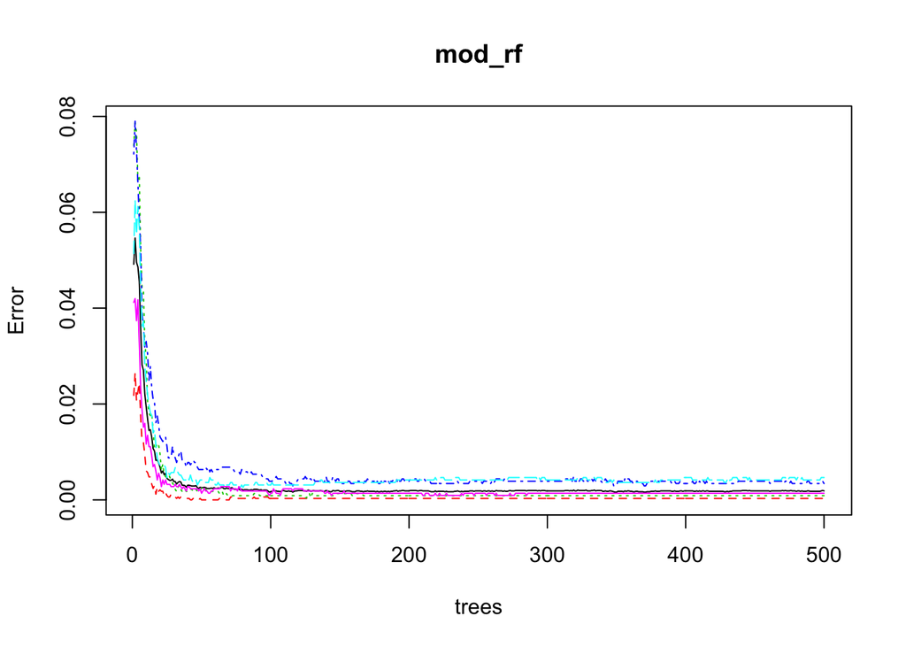

```r
plot(mod_rf)
```

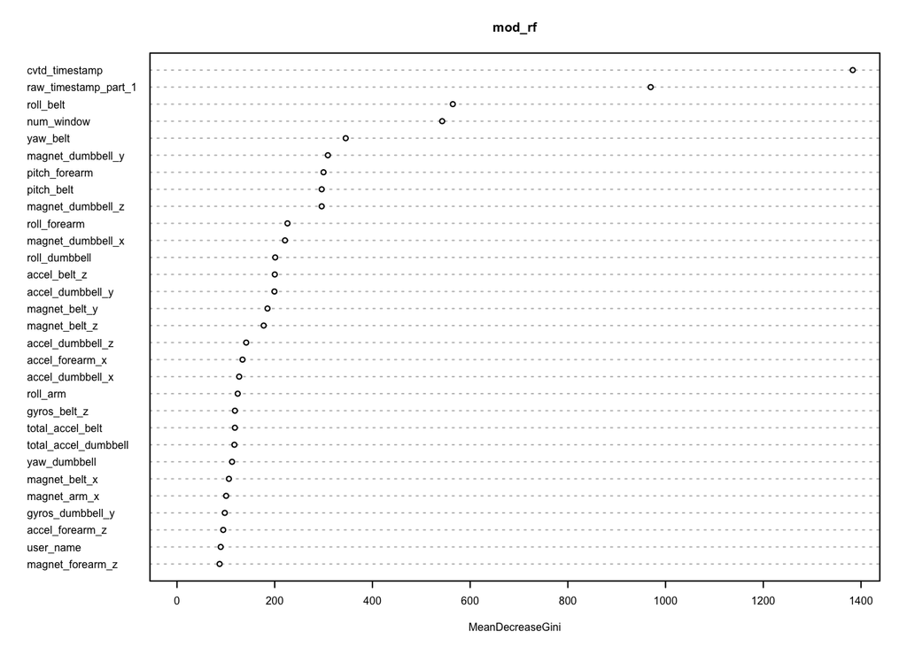

```r
varImpPlot(mod_rf, cex=.5)
```

### ★Predicting results on the test data

With the more accurate model **random forest model**, the prediction results as the following:

```r
predict3 <- predict(mod_rf, newdata = test)
predict3
```

[output not shown]